# Week 1: Introduction to Machine Learning

## Week1 – Introduction

```python
EE0848
Machine Learning
for SP
```

## Today

Syllabus

Course overview

Machine Learning Types

Supervised

Unsupervised

Reinforcement

Machine Learning Workflow

EE0848 - Machine Learning for SP

## Weekly schedule

EE0848 - Machine Learning for SP

## Assesments

Grading:

Project : 30%

Midterm Exam: 25%

Final Exam: 30%

Quizzes: 15%

EE0848 - Machine Learning for SP

## Final Project

Students will work individually or in small groups (of 3 at most) on a real-world machine learning project.

They will choose a dataset, formulate a problem, apply appropriate machine learning techniques, evaluate their models, and present their findings in a report and a short presentation.

EE0848 - Machine Learning for SP

## Learning Outcomes

```python
Explain key ML concepts, types.
Implement and evaluate regression and classification models.
Use metrics, cross-validation, and regularization to optimize models.
Implement bagging and boosting techniques for improved accuracy.
Perform clustering on datasets.
Design basic MLP and CNN architectures for deep learning applications.
```

EE0848 - Machine Learning for SP

## Recommended Books and Resources

```python
Books:
Introduction to Machine Learning with Python: A Guide for Data Scientists by Andreas C. Müller and Sarah Guido
Machine Learning with PyTorch and Scikit-Learn (2022) by Sebastian Raschka, Yuxi (Hayden) Liu, and Vahid Mirjalili
The Elements of Statistical Learning by Trevor Hastie, Robert Tibshirani, and Jerome Friedman
Deep Learning by Ian Goodfellow, Yoshua Bengio, and Aaron Courville
Online Resources:
Scikit-learn Documentation: https://scikit-learn.org/stable/
PyTorch Documentation: https://pytorch.org/
Kaggle: https://www.kaggle.com/
Fast.ai: https://www.fast.ai/
Towards Data Science (Medium): https://towardsdatascience.com/
```

EE0848 - Machine Learning for SP

## Reference Books

EE0848 - Machine Learning for SP

[figure not shown]

[figure not shown]

[figure not shown]

## Python Tools for Machine Learning

EE0848 - Machine Learning for SP

## Software & Tools for Machine Learning

Software & Tools

Python: https://www.python.org/

Jupyter Notebook: https://jupyter.org/

Google Colab: https://colab.research.google.com/

Libraries

NumPy: https://numpy.org/

Pandas: https://pandas.pydata.org/

Scikit-learn: https://scikit-learn.org/

Matplotlib: https://matplotlib.org/

Seaborn: https://seaborn.pydata.org/

PyTorch: https://pytorch.org/

EE0848 - Machine Learning for SP

## Machine Learning

## What is Machine Learning?

```python
Machine learning is a subfield of artificial intelligence (AI) that focuses on enabling systems
to learn from data,
identify patterns, and
make decisions with minimal human intervention
```

EE0848 - Machine Learning for SP

## Why is Machine Learning Important Today?

```python
Explosion of Data (Big Data)
Increased Computing Power
Advancements in Algorithms
Demand for Automation and Intelligent Systems
Wide Range of Applications
```

EE0848 - Machine Learning for SP

## Machine Learning vs. Traditional Programming

```python
Traditional Programming:
Explicitly programmed rules, input data, output results.
Machine Learning:
Learns rules from data, input data and desired output, output learned rules.
```

EE0848 - Machine Learning for SP

## Types of Machine Learning

Supervised

Unsupervised

Reinforcement Learning

EE0848 - Machine Learning for SP

## Supervised Learning

```python
Learns from labeled data (input-output pairs).
Goal:
Predict the output for new, unseen inputs.
Examples:
Image classification,
spam detection,
house price prediction.
```

Classification

Regression

EE0848 - Machine Learning for SP

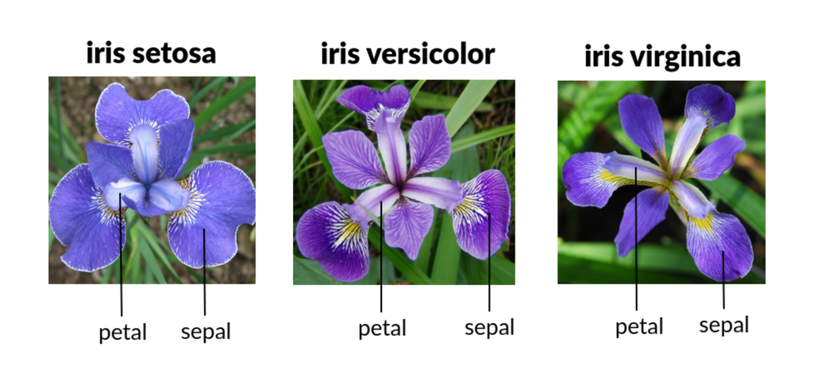

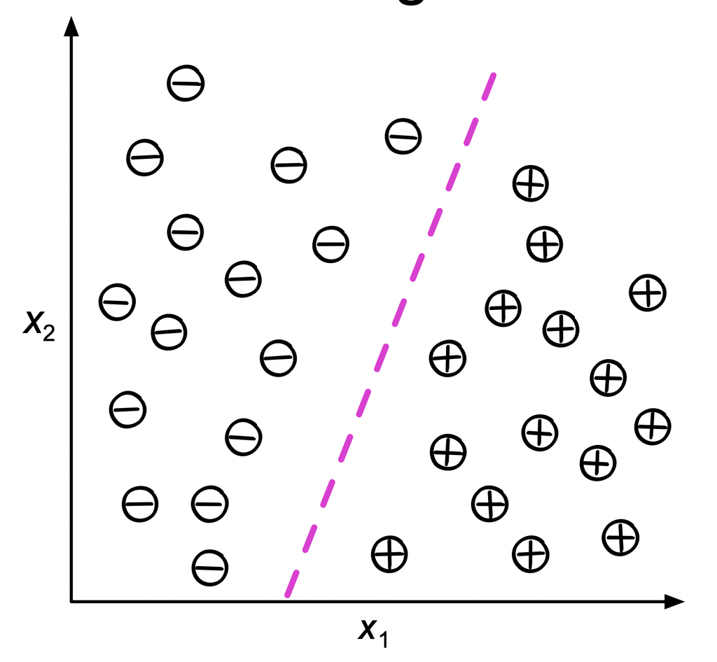

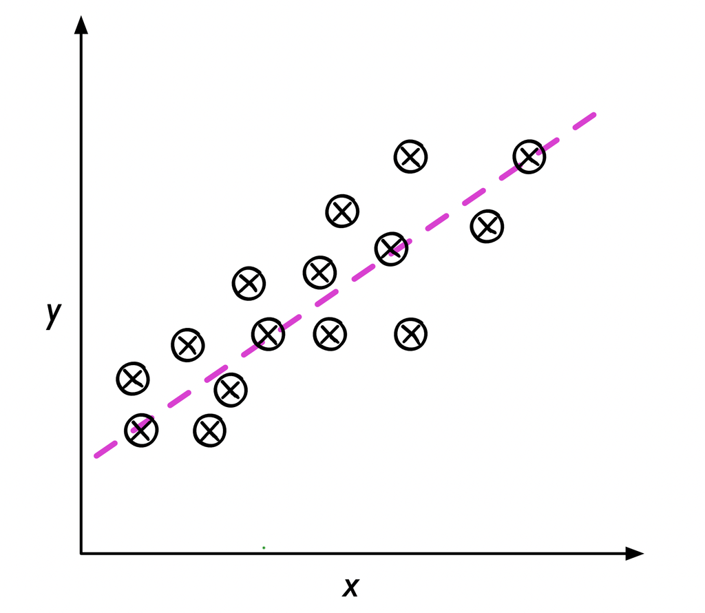

## Supervised Learning: Key Concepts

ex. Fisher’s Iris Data

training

examples

… … … … … …

… … … … … …

classes/

labels

features

```python
150 iris specimens
50 specimens from each of three species
```

Training Data

Features

Labels

Model

EE0848 - Machine Learning for SP

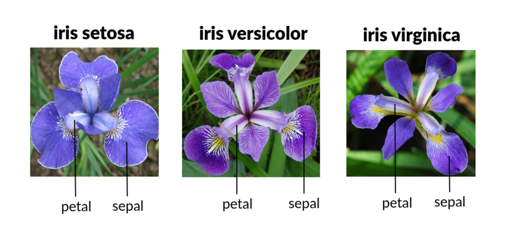

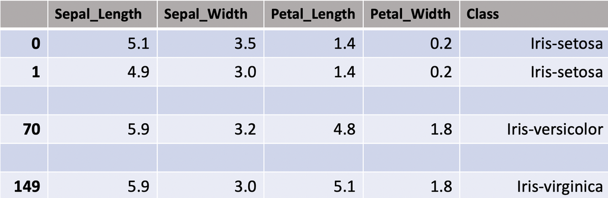

## Supervised Learning: Example

Task: Predict house price based on size.

Label: House price.

Model: Linear Regression.

EE0848 - Machine Learning for SP

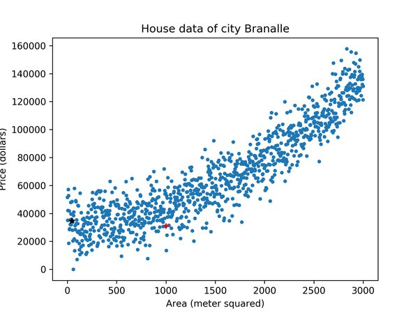

## Unsupervised Learning

```python
Learns from unlabeled data (only inputs, no outputs).
Goal:
Discover hidden patterns, structures, and relationships in the data.
Examples:
Customer segmentation,
anomaly detection,
dimensionality reduction.
```

EE0848 - Machine Learning for SP

## Unsupervised Learning: Example

Task: Group similar customers together.

Features: Customer demographics, purchase history, etc.

Model: K-means clustering

EE0848 - Machine Learning for SP

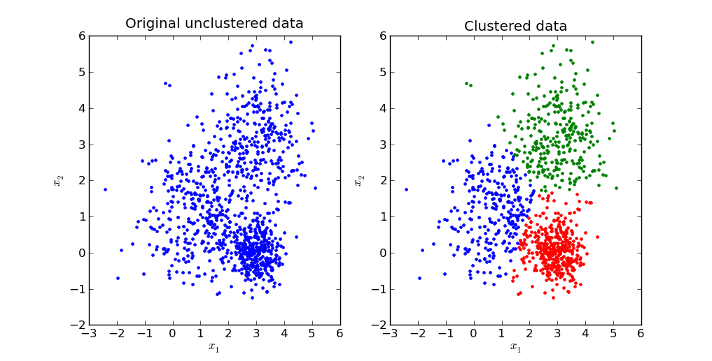

## Reinforcement Learning

An agent learns to interact with an environment by taking actions and receiving rewards.

Goal:

Learn an optimal policy (sequence of actions) to maximize cumulative reward.

Examples:

Game playing, robotics, resource management, reasoning models

EE0848 - Machine Learning for SP

## Reinforcement Learning

```python
Agent: The learner and decision-maker.
Environment: The world the agent interacts with.
State: The current situation.
Action: What the agent does.
Reward: Feedback from the environment.
```

EE0848 - Machine Learning for SP

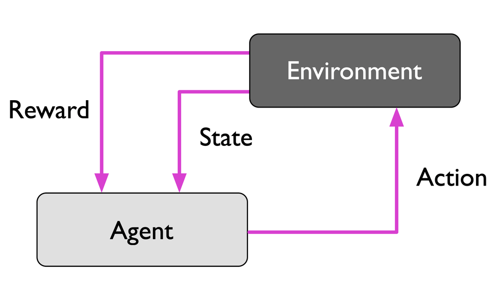

## Reinforcement Learning Example: Robot Vacuum Cleaner

```python
Agent: The robot vacuum cleaner.
Environment: A room with dust and obstacles (walls, furniture).
State: The robot's current position and the cleanliness of the surrounding area.
Action: The robot can move (left, right, forward, backward, clean, stop).
Reward:
+10 for cleaning a dusty spot.
-5 for hitting a wall or obstacle.
-1 for moving but not finding dust.
-5 for revisiting recently cleaned areas (to avoid redundancy).
```

EE0848 - Machine Learning for SP

## Google DeepMind’s Deep Q-learning playing Atari Breakout! - YouTube

EE0848 - Machine Learning for SP

[figure not shown]

## Applications of Machine Learning

Self-driving cars,

Medical diagnosis,

Fraud detection,

Recommendation systems.

EE0848 - Machine Learning for SP

## The Machine Learning Workflow

Problem Definition

Data Collection & Preparation

Model Selection

Training

Evaluation

Tuning

Deployment

EE0848 - Machine Learning for SP

## Step 1: Problem Definition

Clearly define the problem you want to solve.

What are your goals and objectives?

What type of ML problem is it (classification, regression, clustering, etc.)?

What data do you need?

EE0848 - Machine Learning for SP

## Step 2: Data Collection and Preparation

```python
Gather data from various sources.
Clean and preprocess the data:
Handle missing values
Outlier detection
Feature scaling
Data transformation
Split data into training, validation, and testing sets.
```

EE0848 - Machine Learning for SP

## Step 3: Model Selection

Choose an appropriate ML algorithm based on the problem and data.

Consider factors like:

Type of problem (supervised, unsupervised)

Data characteristics

Interpretability

Computational resources.

EE0848 - Machine Learning for SP

## Step 4: Model Training

Feed the training data to the chosen algorithm.

The algorithm learns the patterns and relationships in the data.

Adjust model parameters to minimize the error or loss function.

EE0848 - Machine Learning for SP

## Step 5: Model Evaluation

Assess the model’s performance on the validation/test data.

Use appropriate evaluation metrics (accuracy, precision, recall, F1-score, MSE, etc.).

Determine if the model meets the desired performance goals.

EE0848 - Machine Learning for SP

## Step 6: Model Tuning

Fine-tune the model’s hyperparameters to improve performance.

Use techniques like cross-validation to find the optimal hyperparameter settings.

Iterate between training, evaluation, and tuning.

EE0848 - Machine Learning for SP

## Step 7: Model Deployment

Integrate the trained model into a real-world application or system.

Monitor the model’s performance over time.

Retrain the model periodically with new data.

EE0848 - Machine Learning for SP

## Feature Extraction and Scaling

Model Selection

Cross-Validation

Performance Metrics

Hyperparameter Optimization

Compare model outuputs to targets

Output

Raw Data

Learning Algorithm

Preprocessing

Training Set

New

Data

Learned Model

Final Model

Labels

Labels

Labels

(Predicted)

Test Set

Split the data into train and test sets

Labels

Model deployment

Model

Evaluation

Learning/Training

Preprocessing

Repeat if not satisfied with the model

EE0848 - Machine Learning for SP

## Data Concepts

```python
Features: Input variables used for prediction.
Labels/Targets: Output variables to be predicted.
Training Set: Data used to train the ML model.
Validation Set: Data used to tune model hyperparameters.
Test Set: Data used to evaluate the final model's performance.
```

ex. Fisher’s Iris Data

Dataset (Train,Val,Test)

… … … … … …

… … … … … …

classes/

labels

features

EE0848 - Machine Learning for SP

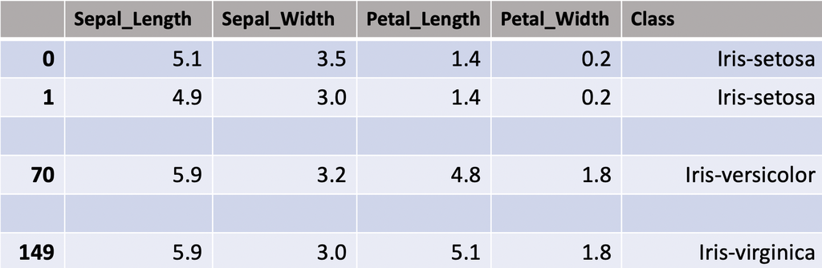